# Estimating CDF and PDF

Sean Schilk

2/3/26

# **Question 1: Cumulative Distribution Function (CDF) Estimation**

The following failure times (in hours) were observed for 8 electronic components:

23, 45, 67, 89, 112, 156, 189, 245

1. Write an R function implementing the ECDF $\hat{F}_n(t)$ according to its mathematical definition. Validate your implementation using R’s ecdf() function on the given data, with comparison based on their step functions.

First we write my R function:

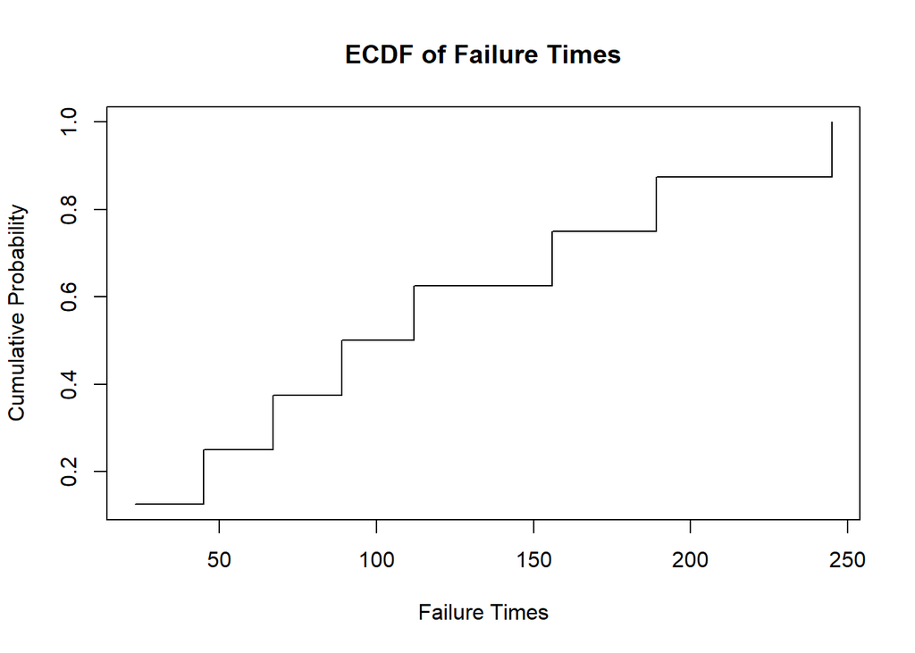

```r
times <- c(23, 45, 67, 89, 112, 156, 189, 245)
uniq.time <- sort(unique(times))   # need to sort the data values
## R function
my.ECDF <- function(indat, outx){
  # outx - a vector of given values
  freq.table <- table(indat)                          # frequency table
  uniq <- as.numeric(names(freq.table))          # unique data values
  rep.time <- as.vector(freq.table)                   # frequencies of the unique data values
  cum.rel.feq <- cumsum(rep.time)/sum(rep.time)       # cumulative relative frequencies: CDF
  cum.prob <- NULL
  for (i in 1:length(outx)){
    intvl.id <- which(uniq <= outx[i])      # identify the index meeting the condition
    cum.prob[i] <- cum.rel.feq[max(intvl.id)] # extract the cumulative prob according to CDF
  }
  cum.prob
}
##
plot(uniq.time, my.ECDF(indat = times, outx = uniq.time), type = "s",
     main = "ECDF of Failure Times",
     xlab = "Failure Times",
     ylab = "Cumulative Probability")
```

Then let’s validate using R’s ecdf function:

```r
# Create empirical CDF
empirical_cdf <- ecdf(times)
ecdf_values <- empirical_cdf(times)

data.frame(
  Time     = times,
  ECDF     = ecdf_values,
  Fraction = paste0(1:8, "/8")
)
```

```
  Time  ECDF Fraction
1   23 0.125      1/8
2   45 0.250      2/8
3   67 0.375      3/8
4   89 0.500      4/8
5  112 0.625      5/8
6  156 0.750      6/8
7  189 0.875      7/8
8  245 1.000      8/8
```

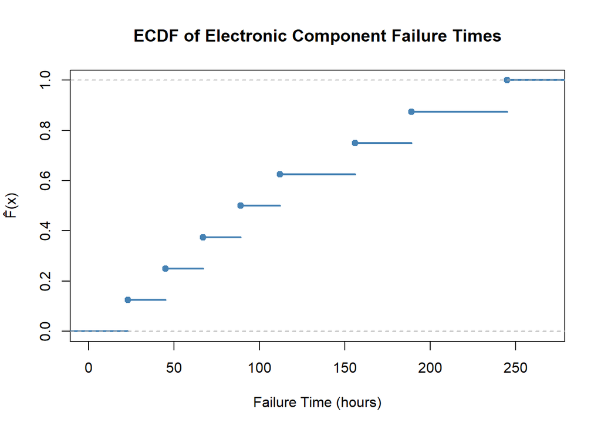

```r
# Plot the ECDF
plot(empirical_cdf,
     main = "ECDF of Electronic Component Failure Times",
     xlab = "Failure Time (hours)",
     ylab = "F̂(x)",
     col  = "steelblue",
     lwd  = 2,
     pch  = 19)
```

As we can see the step function is visually the same to my own function.

2. A colleague claims that the probability of failure before 100 hours is 0.5 based on these data. Do you agree? Explain your reasoning using the empirical cumulative distribution function (ECDF).

The step at 100 is .5 based on the plot. So, according to the data, about 50% of failures occurred at or before 100 hours.

# Question 2: Density Function Estimation

Consider the following failure times from a mechanical system:

12.3, 14.7, 15.2, 16.8, 18.1, 19.4, 20.6, 22.3, 23.9, 25.4 Create a histogram of the data using 3 equally spaced bins. What is the estimated density in each bin? Describe the shape of the histogram’s distribution.

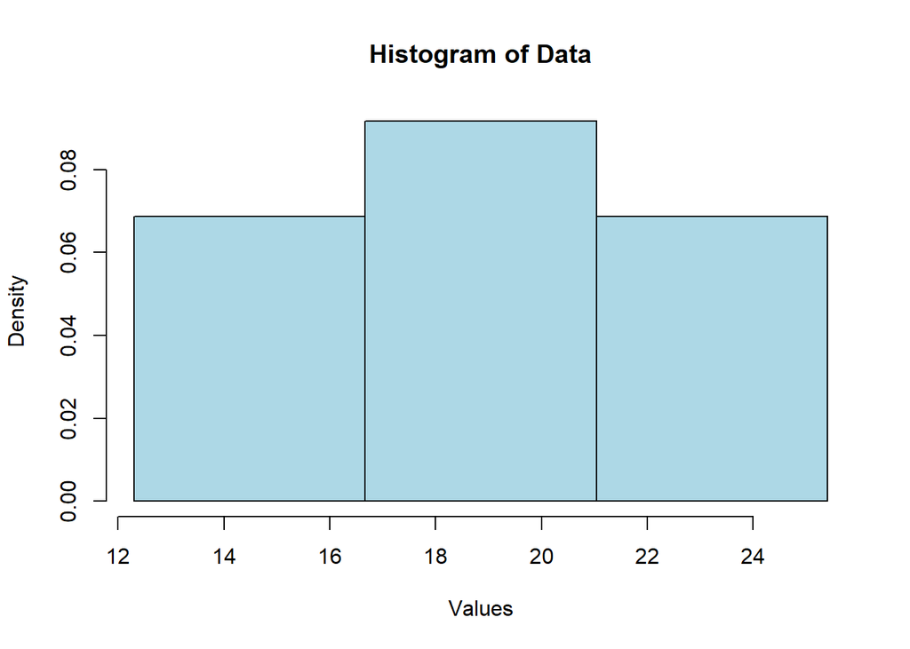

```r
data <- c(12.3, 14.7, 15.2, 16.8, 18.1,
          19.4, 20.6, 22.3, 23.9, 25.4)

breaks <- seq(min(data), max(data), length.out = 4)

hist(data,
     breaks = breaks,
     freq = FALSE,
     main = "Histogram of Data",
     xlab = "Values",
     col = "lightblue")
```

The estimated density of the 3 bins from left to right is .07, .1, .071. The histogram follows a normal distribution.

2. Write an R function that computes kernel density estimates using a Gaussian kernel with h=2. Validate your implementation against R’s built-in density() function.

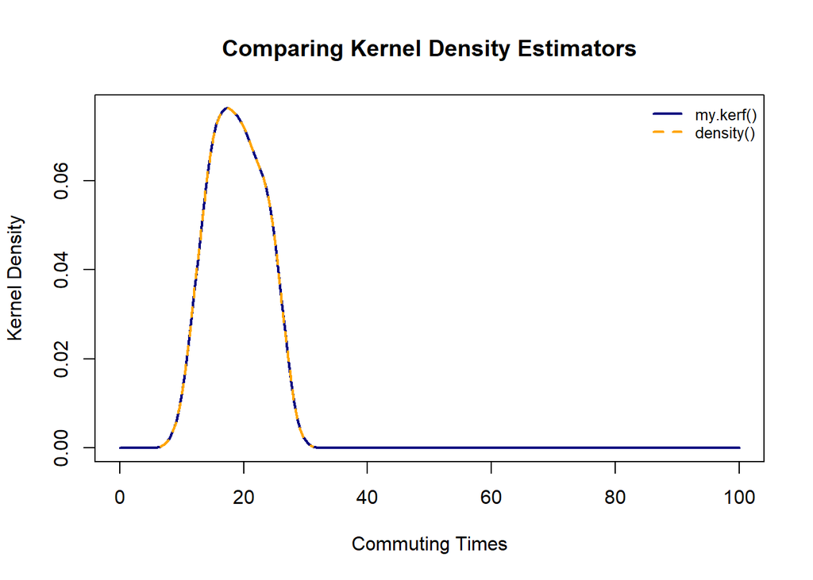

```r
my.kerf <- function(in.data, h, out.x){
  n <- length(in.data)     # sample size
  den <- NULL              # density vector to store output values
  for (i in 1:length(out.x)){
    den[i] <- sum(dnorm(out.x[i], mean=in.data, sd = h))/n  # kernel density formula
  }
  den  # return density values based on the out.x values
}

xx = seq(0,100, length=200)
##
my.den <- my.kerf(in.data = data, h = 2, out.x = xx)
## density()
kde <- density(data, bw = 2, kernel = "gaussian")
##
kde.y <-approx(kde$x, kde$y, xout = xx)$y
## base R plot
plot(xx, my.den, type = "l", main = "Comparing Kernel Density Estimators",
     xlab = "Commuting Times",
     ylab = "Kernel Density",
     lty = 1,
     lwd = 2,
     col = "navy")
## add density curve based on the built-in density()
lines(xx, kde.y, lty = 2, lwd = 2, col = "orange")
legend("topright", c("my.kerf()", "density()"), lty =c(1,2), lwd = rep(2,2),
       col = c("navy", "orange"), cex = 0.8, bty = "n")
```

3. Write a custom R function that computes kernel density estimates using the Epanechnikov kernel with h=2. Validate your implementation by comparing results with R’s built-in density() function for Gaussian kernel estimation.

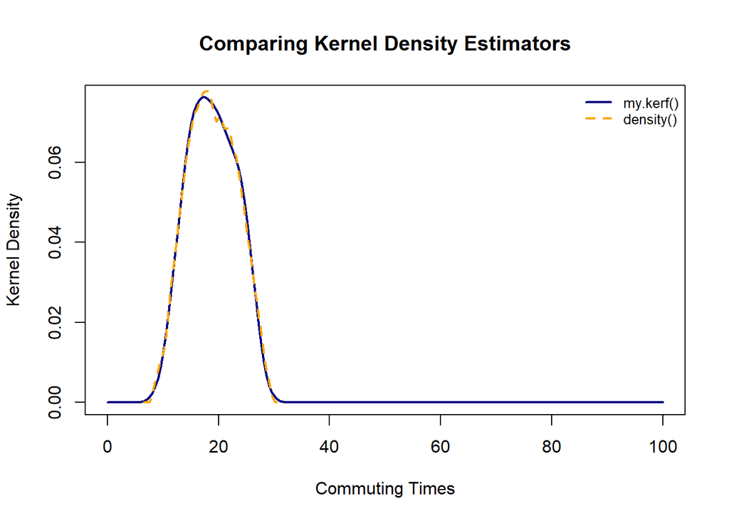

```r
my.den <- my.kerf(in.data = data, h = 2, out.x = xx)
## density()
kde <- density(data, bw = 2, kernel = "epanechnikov")
##
kde.y <-approx(kde$x, kde$y, xout = xx)$y
## base R plot
plot(xx, my.den, type = "l", main = "Comparing Kernel Density Estimators",
     xlab = "Commuting Times",
     ylab = "Kernel Density",
     lty = 1,
     lwd = 2,
     col = "navy")
## add density curve based on the built-in density()
lines(xx, kde.y, lty = 2, lwd = 2, col = "orange")
legend("topright", c("my.kerf()", "density()"), lty =c(1,2), lwd = rep(2,2),
       col = c("navy", "orange"), cex = 0.8, bty = "n")
```

4. How does the choice of kernel (Gaussian vs. Epanechnikov) affect the density estimate? For both kernel estimators applied to this dataset, what happens when we select h=1.5 versus h=2.5?

Gaussian kernel uses a smoother bell shaped curve, which is optimal when we assume normally distributed data. An Epanechnikov kernel gives more weight to nearby observations and zero weight beyond a cutoff distance, producing a curve with a higher peak and less width.

Let’s change our bandwidth for each curve, starting with h=1.5 for both

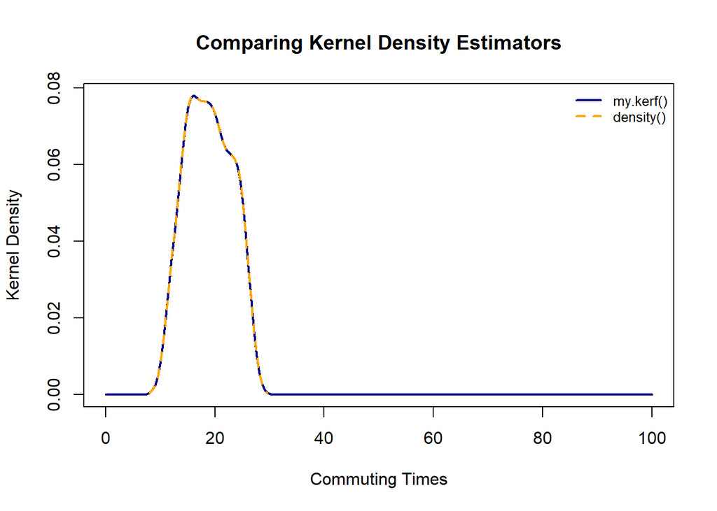

```r
my.den <- my.kerf(in.data = data, h = 1.5, out.x = xx)
## density()
kde <- density(data, bw = 1.5, kernel = "gaussian")
##
kde.y <-approx(kde$x, kde$y, xout = xx)$y
## base R plot
plot(xx, my.den, type = "l", main = "Comparing Kernel Density Estimators",
     xlab = "Commuting Times",
     ylab = "Kernel Density",
     lty = 1,
     lwd = 2,
     col = "navy")
## add density curve based on the built-in density()
lines(xx, kde.y, lty = 2, lwd = 2, col = "orange")
legend("topright", c("my.kerf()", "density()"), lty =c(1,2), lwd = rep(2,2),
       col = c("navy", "orange"), cex = 0.8, bty = "n")
```

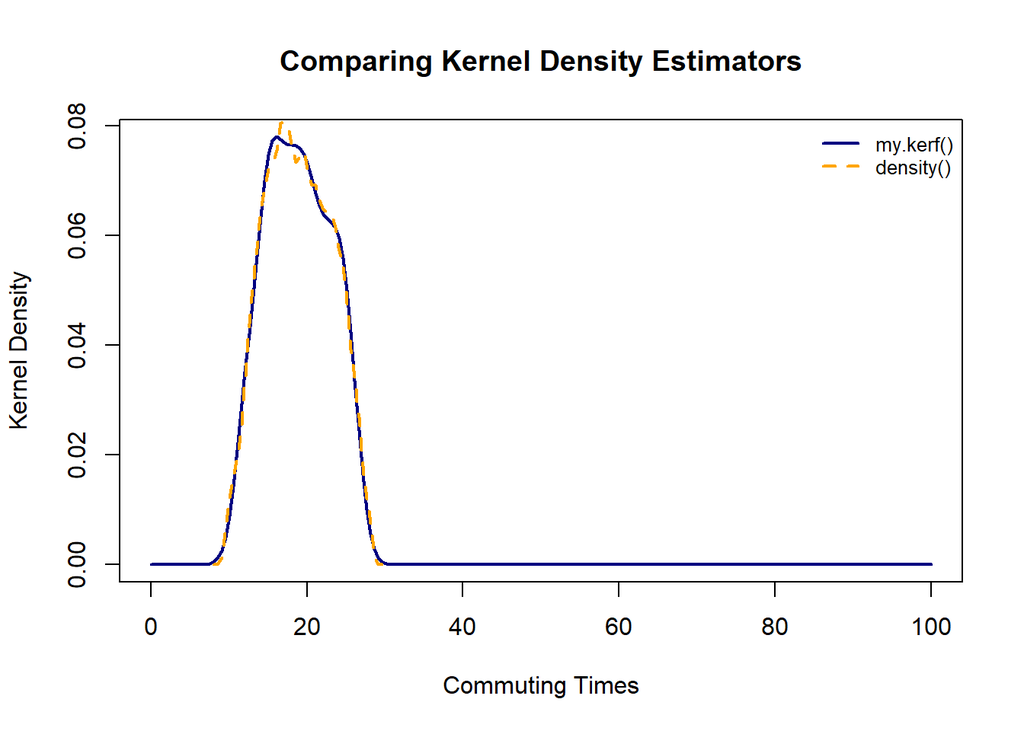

```r
my.den <- my.kerf(in.data = data, h = 1.5, out.x = xx)
## density()
kde <- density(data, bw = 1.5, kernel = "epanechnikov")
##
kde.y <-approx(kde$x, kde$y, xout = xx)$y
## base R plot
plot(xx, my.den, type = "l", main = "Comparing Kernel Density Estimators",
     xlab = "Commuting Times",
     ylab = "Kernel Density",
     lty = 1,
     lwd = 2,
     col = "navy")
## add density curve based on the built-in density()
lines(xx, kde.y, lty = 2, lwd = 2, col = "orange")
legend("topright", c("my.kerf()", "density()"), lty =c(1,2), lwd = rep(2,2),
       col = c("navy", "orange"), cex = 0.8, bty = "n")
```

As we can see, using a smaller h lead to under-smoothing, where we had higher variance.

Let’s increase our h to 2.5 now:

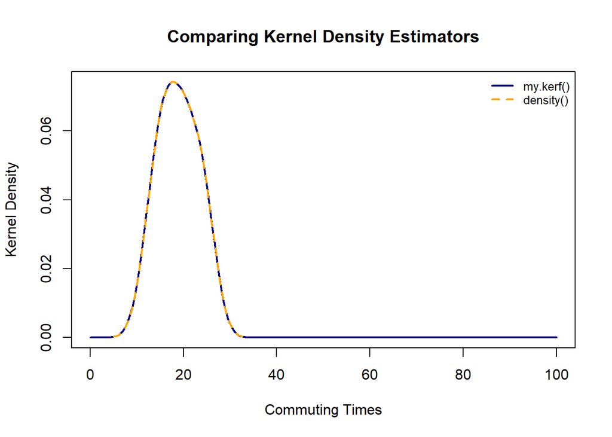

```r
my.den <- my.kerf(in.data = data, h = 2.5, out.x = xx)
## density()
kde <- density(data, bw = 2.5, kernel = "gaussian")
##
kde.y <-approx(kde$x, kde$y, xout = xx)$y
## base R plot
plot(xx, my.den, type = "l", main = "Comparing Kernel Density Estimators",
     xlab = "Commuting Times",
     ylab = "Kernel Density",
     lty = 1,
     lwd = 2,
     col = "navy")
## add density curve based on the built-in density()
lines(xx, kde.y, lty = 2, lwd = 2, col = "orange")
legend("topright", c("my.kerf()", "density()"), lty =c(1,2), lwd = rep(2,2),
       col = c("navy", "orange"), cex = 0.8, bty = "n")
```

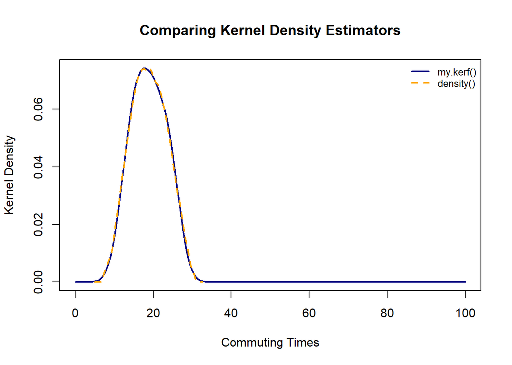

```r
my.den <- my.kerf(in.data = data, h = 2.5, out.x = xx)
## density()
kde <- density(data, bw = 2.5, kernel = "epanechnikov")
##
kde.y <-approx(kde$x, kde$y, xout = xx)$y
## base R plot
plot(xx, my.den, type = "l", main = "Comparing Kernel Density Estimators",
     xlab = "Commuting Times",
     ylab = "Kernel Density",
     lty = 1,
     lwd = 2,
     col = "navy")
## add density curve based on the built-in density()
lines(xx, kde.y, lty = 2, lwd = 2, col = "orange")
legend("topright", c("my.kerf()", "density()"), lty =c(1,2), lwd = rep(2,2),
       col = c("navy", "orange"), cex = 0.8, bty = "n")
```

An increased h can lead to over-smoothing, where we have high bias. Although here we can see our approximation fit better than a bandwidth of 2.